# Quantitative Methods – Day 4: Instrumental Variables

Harm H. Schuett

26 December, 2017

```r
graph_from_data_frame <- igraph::graph_from_data_frame
library(tibble)
library(haven)    # read stata files
library(lfe)      # for FE models with instruments
```

# 1 Estimating causal effects indirectly: Instrumental variables

Let’s go back to our original confounding problem:

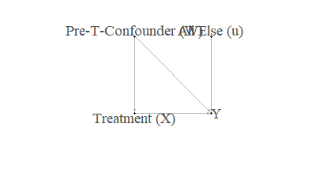

```r
Nodes <- tribble(
  ~nodes,                 ~x, ~y,
  "Pre-T-Confounder (W)", -1,  1,
  "Treatment (X)",        -1,  0,
  "Y",                     1,  0,
  "All Else (u)",          1,  1)
Edges <- tribble(
  ~from,                 ~to,
  "Pre-T-Confounder (W)", "Treatment (X)",
  "Pre-T-Confounder (W)", "Y",
  "Treatment (X)",        "Y",
  "All Else (u)",         "Y")
plot(graph_from_data_frame(vertices=Nodes, d=Edges, directed=TRUE),
     vertex.color="gray30", vertex.size=7,
     label.font=2, vertex.size=30, vertex.label.cex=1.2,
     edge.arrow.size=0.5, edge.color="gray70",
     vertex.label.color="gray30", vertex.label.dist=2,
     vertex.label.degree=c(-pi/2,pi/2, 0, -pi/2))
```

$W$ affects $X$ and $Y$. If we measure the relation between $Y$ and $X$ without accounting for $W$, then we cannot identify the causal effect of $x\rightarrow Y$. This is because parts of the co-movement between $X$ and $Y$ could simply be due $W$ without having any *cause* in $X$.

If we cannot measure $W$, then regression, matching, etc, does not help us in identifying the causal effect of $X$ on $Y$ because we cannot condition on $W$. Sometimes we can help ourselfs by the method of **instrumental variables (IV)**. An instrumental variable has the following form:

[figure not shown]

```r
Nodes <- tribble(
  ~nodes,                 ~x, ~y,
  "Pre-T-Confounder (W)", -1,  1,
  "Treatment (X)",        -1,  0,
  "Y",                     1,  0,
  "All Else (u)",          1,  1,
  "IV",                   -2,  0)
Edges <- tribble(
  ~from,                 ~to,
  "Pre-T-Confounder (W)", "Treatment (X)",
  "Pre-T-Confounder (W)", "Y",
  "Treatment (X)",        "Y",
  "All Else (u)",         "Y",
  "IV",                  "Treatment (X)")
plot(graph_from_data_frame(vertices=Nodes, d=Edges, directed=TRUE),
     vertex.color="gray30", vertex.size=7,
     label.font=2, vertex.size=30, vertex.label.cex=1.2,
     edge.arrow.size=0.5, edge.color=c(rep("gray70", 4), "red"),
     vertex.label.color="gray30", vertex.label.dist=2,
     vertex.label.degree=c(-pi/2,pi/2, 0, -pi/2, pi/2))
```

An instrumental variable is a variable that:

1. Has non-zero association between $IV$ and $X$.
2. Only affects $Y$ through $X$ (exclusion restriction).
3. Is independent of $W$, possibly after conditioning on other predictors. (Ignorability of the instrument)

If these points are given, “random variation” in $IV$ causes random variation in $X$ and we get an *indirect* estimate of the causal effect of $X$ on $Y$.

# 2 Example

Let’s take an example out of Gelman and Hill (2007), pp. 216 to illustrate. This is a randomized-encouragement design. Suppose, we want to estimate the causal effect of watching Sesame Street on letter recognition. Think of a randomized experiment with pre-school children. The treatment $T$ is watching Sesame Street, the control is not watching. The outcome is the score on a test of letter recognition.

Of course, it is not possible to force children to watch a show and whether they watch or not might be related to a confounding variable that also effects letter recognition (such as curiosity maybe.) But, if watching cannot be randomized, what can we do? We can randomize encouragement to watch. Remember an instrument is a variable thought to “randomly” induce variation in the treatment of interest. Of course, we hope that encouragement actually works (point 1: encouragement is associated with actually watching Sesame Street). But that is something we can reasonably check in the data. Let’s load the data and check:

```r
sesame <- read_dta("../data/sesame.dta")
sesame <- zap_formats(sesame)
str(sesame)
```

```
Classes ‘tbl_df’, ‘tbl’ and 'data.frame':   240 obs. of  28 variables:
 $ rownames : num  1 2 3 4 5 6 7 8 9 10 ...
 $ id       : num  1 2 3 4 5 6 7 8 9 10 ...
 $ site     : num  1 1 1 1 1 1 1 1 1 1 ...
 $ sex      : num  1 2 1 1 1 2 2 1 1 2 ...
 $ age      : num  66 67 56 49 69 54 47 51 69 53 ...
 $ viewcat  : num  1 3 3 1 4 3 3 2 4 3 ...
 $ setting  : num  2 2 2 2 2 2 2 2 2 2 ...
 $ viewenc  : num  1 1 2 2 2 2 2 1 1 1 ...
 $ prebody  : num  16 30 22 23 32 29 23 32 27 30 ...
 $ prelet   : num  23 26 14 11 47 26 12 48 44 38 ...
 $ preform  : num  12 9 9 10 15 10 11 19 18 17 ...
 $ prenumb  : num  40 39 9 14 51 33 13 52 42 31 ...
 $ prerelat : num  14 16 9 9 17 14 11 15 15 10 ...
 $ preclasf : num  20 22 8 13 22 14 12 23 20 17 ...
```

[output cut: 18 more lines]

```r
# Quick way of creating a frequency table:
table(sesame$encour, sesame$viewcat)
```

```
     1  2  3  4
  0 40 13 17 18
  1 14 47 47 44
```

So, it looks like encouraging is associate with watching more Sesame Street.

We can motivate and illustrate the instrumental variable approach using regressions. The problem is that $corr(T,\epsilon_i)\neq0$ in the below equation and thus we cannot identify $\beta_1$.

$$y = \beta_0 + \beta_1 T + \epsilon_i$$

Now assume we have a variable $IV$ and can reason that $T$ and $IV$ are related like this:

$$T = \gamma_0 + \gamma_1 IV + v_i$$

The ignorability and exclusion assumptions can be informally expressed as $corr(IV,\epsilon_i)=0$ and $corr(IV,v_i)=0$. Also $\gamma_1$ must be non-zero.

Now how does this help us identifying $\beta_1$? Let’s substitute one into the other equation:

$$y = \beta_0 + \beta_1 (\gamma_0 + \gamma_1 IV + v_i) + \epsilon_i$$

And after rearranging:

$$y = (\beta_0 + \beta_1\gamma_0) + \beta_1\gamma_1 IV + (\beta_1v_i + \epsilon_i)$$
$$y = \delta_0 + \delta_1 IV + u_i$$
Now, since $\delta_1=\beta_1\gamma_1$ we can simply compute $\delta_1/\gamma_1$ to get $\beta_1$:

```r
fit_1a <- lm (regular ~ encour, data=sesame)
summary(fit_1a)
```

```
Call:
lm(formula = regular ~ encour, data = sesame)

Residuals:
     Min       1Q   Median       3Q      Max
-0.90789  0.09211  0.09211  0.09211  0.45455

Coefficients:
            Estimate Std. Error t value Pr(>|t|)
(Intercept)  0.54545    0.04060  13.434  < 2e-16 ***
encour       0.36244    0.05102   7.104  1.4e-11 ***
---
Signif. codes:  0 ‘***’ 0.001 ‘**’ 0.01 ‘*’ 0.05 ‘.’ 0.1 ‘ ’ 1

Residual standard error: 0.3809 on 238 degrees of freedom
Multiple R-squared:  0.1749,    Adjusted R-squared:  0.1715
F-statistic: 50.46 on 1 and 238 DF,  p-value: 1.397e-11
```

```r
fit_1b <- lm (postlet ~ encour, data=sesame)
summary(fit_1b)
```

```
Call:
lm(formula = postlet ~ encour, data = sesame)

Residuals:
    Min      1Q  Median      3Q     Max
-24.920 -10.796  -4.796  12.423  38.080

Coefficients:
            Estimate Std. Error t value Pr(>|t|)
(Intercept)   24.920      1.421   17.54   <2e-16 ***
encour         2.876      1.786    1.61    0.109
---
Signif. codes:  0 ‘***’ 0.001 ‘**’ 0.01 ‘*’ 0.05 ‘.’ 0.1 ‘ ’ 1

Residual standard error: 13.33 on 238 degrees of freedom
Multiple R-squared:  0.01078,   Adjusted R-squared:  0.006623
F-statistic: 2.593 on 1 and 238 DF,  p-value: 0.1086
```

```r
iv_est_1 <- coef (fit_1b)["encour"]/coef (fit_1a)["encour"]
print(iv_est_1)
```

```
  encour
7.933993
```

But again, it is crucial that $IV$ does not appear in the first outcome equation itself (exclusion restriction) and not have correlations with any of the two error terms.

You don’t really want to do it this way though. For example, there is no easy way to get the right standard errors in this approach. This is simply to show the rationale behind the estimator. First of all, we usually do a 2-stage least squares procedure:

```r
fit_2a <- lm(regular ~ encour, data=sesame)
sesame$regular_hat <- fit_2a$fitted
fit_2b <- lm(postlet ~ regular_hat, data=sesame)
summary(fit_2b)
```

```
Call:
lm(formula = postlet ~ regular_hat, data = sesame)

Residuals:
    Min      1Q  Median      3Q     Max
-24.920 -10.796  -4.796  12.423  38.080

Coefficients:
            Estimate Std. Error t value Pr(>|t|)
(Intercept)   20.593      3.914   5.261 3.19e-07 ***
regular_hat    7.934      4.927   1.610    0.109
---
Signif. codes:  0 ‘***’ 0.001 ‘**’ 0.01 ‘*’ 0.05 ‘.’ 0.1 ‘ ’ 1

Residual standard error: 13.33 on 238 degrees of freedom
Multiple R-squared:  0.01078,   Adjusted R-squared:  0.006623
F-statistic: 2.593 on 1 and 238 DF,  p-value: 0.1086
```

You can see we get the same coefficient. However, the standard error is still wrong because we need to account for the 1st stage variation when computing this standard error. Thus, you shouldn’t usually do this on your own. (see Gelman and Hill 2007, Wooldridge (2010) for the formula to compute the standard errors).

```r
# the felm model estimator has support for IV estimation, although the syntax is a bit strange:
ivfit_1 <- felm(postlet ~ 1 |0 | (regular ~ encour) |0, data=sesame)
summary(ivfit_1)
```

```
Call:
   felm(formula = postlet ~ 1 | 0 | (regular ~ encour) | 0, data = sesame)

Residuals:
    Min      1Q  Median      3Q     Max
-20.593  -9.593  -4.527  10.723  34.473

Coefficients:
               Estimate Std. Error t value Pr(>|t|)
(Intercept)      20.593      3.659   5.628 5.11e-08 ***
`regular(fit)`    7.934      4.606   1.723   0.0863 .
---
Signif. codes:  0 ‘***’ 0.001 ‘**’ 0.01 ‘*’ 0.05 ‘.’ 0.1 ‘ ’ 1

Residual standard error: 12.46 on 238 degrees of freedom
Multiple R-squared(full model): 0.1355   Adjusted R-squared: 0.1318
Multiple R-squared(proj model): 0.1355   Adjusted R-squared: 0.1318
F-statistic(full model):2.967 on 1 and 238 DF, p-value: 0.08626
F-statistic(proj model): 2.967 on 1 and 238 DF, p-value: 0.08626
F-statistic(endog. vars):2.967 on 1 and 238 DF, p-value: 0.08626
```

> It turns out that the randomization for this experiment took place within sites and settings; it is therefore appropriate to control for these covariates in estimating the treatment effect. Additionally, pre-test scores are available that are highly predictive of post-test scores. Our preferred model would control for all of these predictors. We can calculate the same ratio (intent-to-treat effect divided by effect of encouragement on viewing) as before using models that include these additional predictors but pulling out only the coefficients on *encour* for the ratio:

Or in regression terms:

```r
fit_3a <- lm(regular  ~ encour + prelet + as.factor(site) + setting, data=sesame)
sesame$regular_hat <- fit_3a$fitted
fit_3b <- lm(postlet ~ regular_hat + prelet + as.factor(site) + setting, data=sesame)
summary(fit_3b)
```

```
Call:
lm(formula = postlet ~ regular_hat + prelet + as.factor(site) +
    setting, data = sesame)

Residuals:
    Min      1Q  Median      3Q     Max
-25.308  -6.736  -1.208   6.106  26.652

Coefficients:
                 Estimate Std. Error t value Pr(>|t|)
(Intercept)       1.21922    4.76594   0.256 0.798317
regular_hat      14.03398    4.04500   3.469 0.000622 ***
prelet            0.70000    0.07855   8.912  < 2e-16 ***
as.factor(site)2  8.40258    1.82757   4.598 7.02e-06 ***
as.factor(site)3 -3.94465    1.80821  -2.182 0.030150 *
as.factor(site)4  0.93894    2.45109   0.383 0.702017
as.factor(site)5  2.76235    2.89124   0.955 0.340359
setting           1.59584    1.47939   1.079 0.281833
---
Signif. codes:  0 ‘***’ 0.001 ‘**’ 0.01 ‘*’ 0.05 ‘.’ 0.1 ‘ ’ 1

Residual standard error: 9.667 on 232 degrees of freedom
Multiple R-squared:  0.493, Adjusted R-squared:  0.4777
F-statistic: 32.22 on 7 and 232 DF,  p-value: < 2.2e-16
```

again, standard errors not correct. Better:

```r
ivfit_2 <- felm(postlet ~ + prelet + as.factor(site) + setting | 0 | (regular ~ encour) |0, data=sesame)
summary(ivfit_2)
```

[output not shown]

So, the estimated effect of watching Sesame Street on the induced watchers is about 14 points in the the letter recognition test. Let’s quickly check the variation in test score to see whether this is economically significant:

```r
quantile(sesame$postlet, c(0.01, 0.025, 0.25, 0.5, 0.75, 0.975, 0.99))
```

```
   1%  2.5%   25%   50%   75% 97.5%   99%
 6.39  9.95 15.00 23.00 39.25 51.00 52.61
```

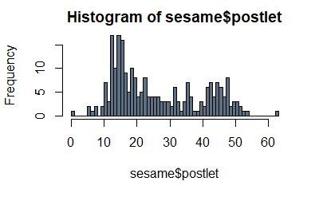

```r
# don't need to load ggplot this time for only creating one simple histogram
hist(sesame$postlet, breaks=50, col=rgb(0.2, 0.3, 0.4, 0.8))
```

So, it looks like this is quite a significant effect.

# 3 Local average treatment effects

If you paid careful attention, something might have crossed your mind. First, one could put *encour* into the regression instead of *regular*. In fact, we are doing just that in part of the illustration above. What are we estimating there? It is called an **intent-to-treat (ITT) effect**. We use this ITT to estimate the causal effect of *regular*. But we cannot do this for all kids in this study. We are estimating what is called a **locale average treatement effect (LATE)**. This is because you cannot “encourage” all kids in this study. “The exclusion restriction implies that there is no effect of the instrument (encouragement) on the outcomes for always-watchers and for never-watchers.” Those kids cannot be encouraged and thus we cannot estimate a causal effect of watching Sesame Street for them.

# 4 Problems with instrumental variables

Instrumental variables is a very neat and powerful way of circumventing confounding bias. However, it all rests on two important caveats:

## 4.1 Weak instruments

Of course, all of the above arguments rest on having a good instrument – an $IV$ that is highly correlated with $T$. If you have a weak instrument things can get messy as your estimates of the treatment effect become very imprecise and potentially even worse than a biased OLS. This goes back to the bias - variance trade-off and the dart board analogy that we had earlier. You might thrown unbiased darts. But if you have only one throw and that throw has a large potential spread, you might actually prefer a biased throw with less spread.

The problem is the first stage of computing predictors ($T ~ IV$). “A weak first stage relationship results in variation of predicted values well below that of the original regressors, producing less efficient estimates than OLS. Weak instruments also produce biased coefficients with highly non-normal distributions whose tail variation may be much greater than believed, generating empirical rejection rates under the null much greater than nominal size.” (Young 2017, 3)

There are tests for weak instruments in the literature. For instance, a classic one is to compute the F-statistic from the first stage regression and see how “strongly” the null of all coefficients explaining $T$ is rejected. However, while still common practice in many applied areas, it has become criticized lately (Young 2017). The reason is that F-Statistic is not well behaved in finite samples in the presence of weak instruments.

## 4.2 Large sample asymptotics and finite sample problems.

The standard errors calculated in most packages employing 2SLS, are based on asymptotic theory. In order to arrive at a formula for those standard errors, we need to assume a certain distribution of the error term and often, we don’t know that. But we can make arguments what the distribution will converge to (mostly to a normal distribution) if the sample size becomes large enough. So we can compute what the standard errors look like “in the asymptotic limit” of infinite sample size. However, we obviously have only finite data and as such, it is always a bit of an article of faith using asymptotic standard errors for small samples. We will talk about this in much more detail in a later section. The problem is that 2SLS seems to be much more susceptible to such finite sample deviations then normal OLS. This is an ongoing field of research though (See Young 2017), so there is no easy remedy for this, except more data and maybe bootstrapping.

# 5 Excercises

1. Please download and read (Bernile, Bhagwat, and Yonker 2017) before class. You can find it [here](http://www.sciencedirect.com.emedien.ub.uni-muenchen.de/science/article/pii/S0304405X17303215). We will discuss the paper’s assumptions, research design, and instrumental variables strategy in detail.

# 6 References

Bernile, Gennaro, Vineet Bhagwat, and Scott Yonker. 2017. “Board Diversity, Firm Risk, and Corporate Policies.” *Journal of Financial Economics*, (forthcoming).

Gelman, Andrew, and Jennifer Hill. 2007. *Data Analysis Using Regression and Multilevelhierarchical Models*. Cambridge University Press.

Wooldridge, Jeffrey M. 2010. *Econometric Analysis of Cross Section and Panel Data*. MIT Press.

Young, Alwyn. 2017. “Consistency Without Inference: Instrumental Variables in Practical Application.” Working Paper.